# Building a Species Distribution Model

Wessel Mulder & Nathan Michielsen

2025-03-11

## Install and unpack necessary packages

```r
# install.packages("terra")
# install.packages("sf")

library(terra)  # Used for handling raster data (spatial information, such as environmental data)
library(sf)     # Used for working with vector spatial data (shapefiles, points, polygons)
```

## Load in data

As always, we’re going to start by loading in and exploring the data. Remember to change the names of the paths to the different files we load to where you have saved those files locally.

### Spatial range

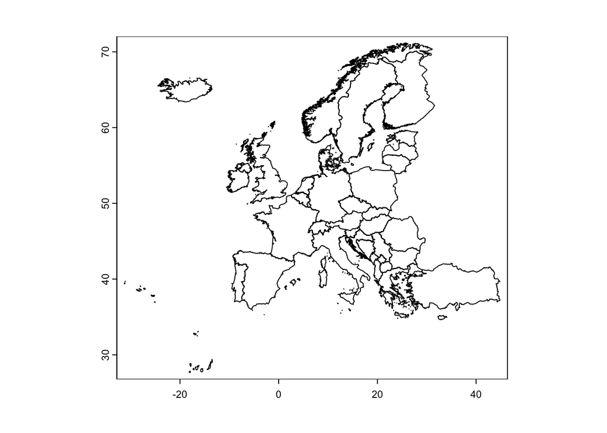

```r
# Load the Europe shapefile (vector data)
europe <- vect("tutorial1_data/europe_simple/europe.shp") # Replace path to  where you saved it!

plot(europe)
```

This file contains the geographic boundaries of Europe. We use it to define the study area and “mask” the occurrence records later on. Masking is a type of spatial filtering which ensures any data falling outside of the mask range will not be considered.

### Environmental data

Next, let’s load a “raster stack” containing our environmental predictors.

```r
# Load environmental predictor variables (raster data)
predictors <- rast("tutorial1_data/tutorial1_stack.tif")
```

Inspect this object. How many “layers” does it contain? What are their names? Do you understand the rest of the information that’s in here?

```r
predictors
```

```
## class       : SpatRaster
## dimensions  : 175, 305, 2  (nrow, ncol, nlyr)
## resolution  : 0.25, 0.25  (x, y)
## extent      : -31.26681, 44.98319, 27.43319, 71.18319  (xmin, xmax, ymin, ymax)
## coord. ref. : lon/lat WGS 84 (EPSG:4326)
## source      : tutorial1_stack.tif
## names       : temperature_annual, precipitation_annual
## min values  :          -21.69689,             3.357333
## max values  :           26.44267,          5309.316895
```

For more information on “SpatRaster” (spatial raster) objects, try what you can find with the help function.

Now let’s look at some of this spatial data.

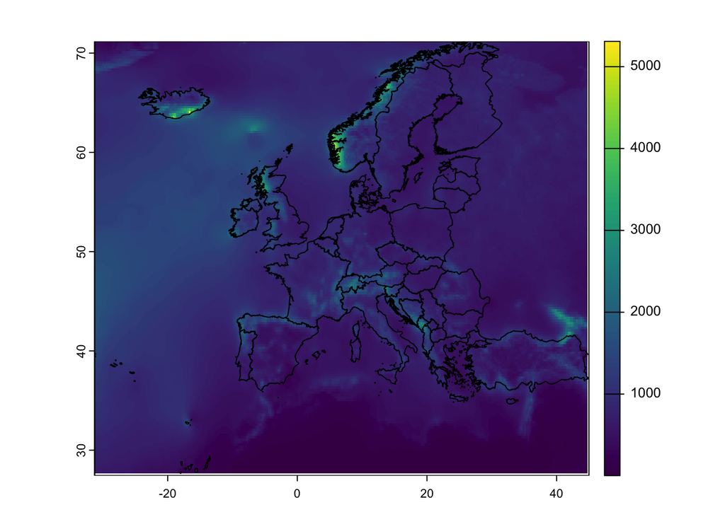

```r
plot(predictors$precipitation_annual)
plot(europe, add=T) # Specifying add = T to add it to previously called graphic
```

### Occurrence records

```r
occurrence <- st_read("tutorial1_data/occurrence_data/occurrence_data.shp")
colnames(occurrence) <- c("occurrenceStatus","presence_absence","geometry") # Rename columns for convenience
```

This shapefile contains the locations where golden eagles have been observed to be present and absent, downloaded from GBIF.com (Global Biodiversity Information Facility).

GBIF also contains absence data, though this is often fewer in number. We have pre-generated “pseudoabsence” data from within the golden eagle’s spatial extent of occurrence, which is included in the occurrence_data shapefile. Using pseudoabsences is a common practice in species distribution modelling when there are more presence records than absence records.

Now let’s plot these occurrence records over annual temperature.

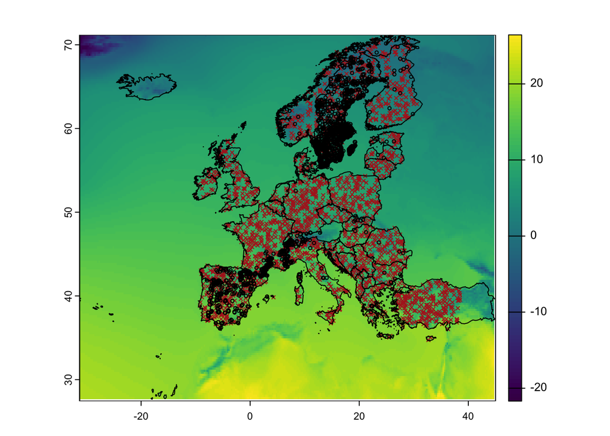

```r
plot(predictors$temperature_annual)
plot(occurrence$geometry[occurrence$presence_absence == 0], # Absences
     col = "firebrick", # Color of symbols
     pch = 4, # Shape of symbols
     cex = 0.5, # Size of symbols
     add=T)
plot(occurrence$geometry[occurrence$presence_absence == 1], # Presences
     pch = 1,
     cex = 0.5,
     add=T)
plot(europe, add=T)
```

## Extract and combine data

Let’s produce a data frame that contains both the occurrence records and the environmental data, while retaining the spatial information of both.

terra has a neat function for this called extract()

```r
df <- extract(predictors, occurrence, bind=TRUE) # We specify bind=TRUE to ensure all information is retained
df$presence_absence <- as.factor(df$presence_absence)
```

We have everything we need to produce our SDM now, so let’s do it.

## Produce the SDM

```r
# Fit a binomial Generalized Linear Model (GLM)
sdm <- glm(presence_absence ~ temperature_annual + precipitation_annual,
          family = binomial,  # Specifies that this is a logistic regression (binomial response)
          data = df)
```

Why are we fitting a binomial GLM here?

Let’s investigate the model summary.

```r
# Display the model summary (coefficients, significance, model fit statistics)
summary(sdm)
```

```
##
## Call:
## glm(formula = presence_absence ~ temperature_annual + precipitation_annual,
##     family = binomial, data = df)
##
## Coefficients:
##                        Estimate Std. Error z value Pr(>|z|)
## (Intercept)           1.878e+00  1.222e-01  15.372   <2e-16 ***
## temperature_annual   -1.461e-01  8.094e-03 -18.049   <2e-16 ***
## precipitation_annual -9.150e-04  9.823e-05  -9.315   <2e-16 ***
## ---
## Signif. codes:  0 '***' 0.001 '**' 0.01 '*' 0.05 '.' 0.1 ' ' 1
##
## (Dispersion parameter for binomial family taken to be 1)
##
##     Null deviance: 5862.0  on 4231  degrees of freedom
## Residual deviance: 5468.4  on 4229  degrees of freedom
## AIC: 5474.4
##
## Number of Fisher Scoring iterations: 4
```

This kind of output should look familiar. What can we tell about the golden eagle’s climatic niche?

## Predict the probability of occurrence

We can predict the probability of occurrence of golden eagle’s using the relationship we found between climate and occurrence, and our climatic data.

For this we use the predict() function in terra.

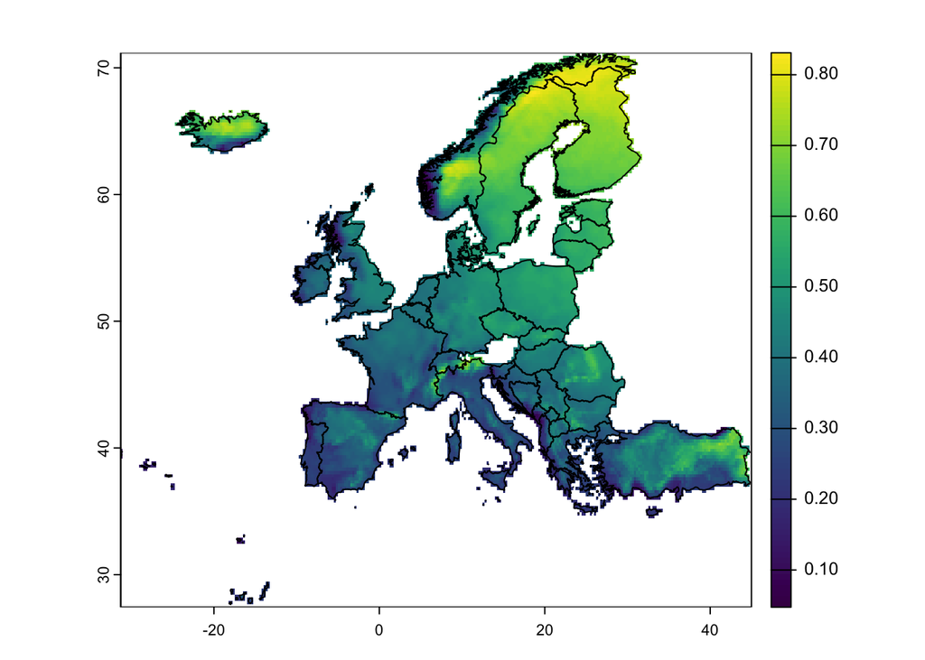

```r
predicted_suitability <- terra::predict(predictors,sdm,type='response')
predicted_suitability <- mask(predicted_suitability,europe) # Mask predictions to European geography
plot(predicted_suitability)
plot(europe, add=T)
```

Isn’t that marvelous?

So far so good. If you feel so inclined, see how this map of predicted suitable habitat compares to the known distribution of golden eagles. You can find this on the IUCN red list page for golden eagles.